# Experiment 2 Analysis

Bonan Zhao

10/17/2021

```r
# Packages
library(tidyverse)
library(nnet) # For multinomial logistic regression

# Data sources
load('./exp_2/data/mturk_main.Rdata')
load('./exp_2/data/labels.Rdata')
load('./exp_2/data/models.Rdata')
tasks = read.csv('./exp_2/data/tasks.csv')
```

# Generalization consistency

For each condition we conducted Fisher’s exact test on the contingency table of selecting each possible result per trial. For all four conditions, p < 0.001.

```r
tests = df.tw %>%
    filter(grepl('gen',sid)) %>%
    mutate(trial=as.numeric(substr(sid,8,9))) %>%
    mutate(result=as.character(result)) %>%
    select(ix, condition, trial, result) %>%
    mutate(condition=as.factor(condition), trial=as.factor(trial), result=as.factor(result))

fisher_test<-function(cond, data=tests){
    x = data%>%filter(condition==cond)
    return(fisher.test(table(x$trial, x$result), simulate.p.value=TRUE, B=10000))
}

fisher_test('A1')
```

```
##
##  Fisher's Exact Test for Count Data with simulated p-value (based on
##  10000 replicates)
##
## data:  table(x$trial, x$result)
## p-value = 9.999e-05
## alternative hypothesis: two.sided
```

```r
fisher_test('A2')
```

```
##
##  Fisher's Exact Test for Count Data with simulated p-value (based on
##  10000 replicates)
##
## data:  table(x$trial, x$result)
## p-value = 9.999e-05
## alternative hypothesis: two.sided
```

```r
fisher_test('A3')
```

```
##
##  Fisher's Exact Test for Count Data with simulated p-value (based on
##  10000 replicates)
##
## data:  table(x$trial, x$result)
## p-value = 9.999e-05
## alternative hypothesis: two.sided
```

```r
fisher_test('A4')
```

```
##
##  Fisher's Exact Test for Count Data with simulated p-value (based on
##  10000 replicates)
##
## data:  table(x$trial, x$result)
## p-value = 9.999e-05
## alternative hypothesis: two.sided
```

As with Experiment 1, we measured inter-person consistency in generalization predictions computing Cronbach’s alpha for the sixteen generalization tasks per condition (excluding the two catch-trials), totalling $4 \times 16 = 64$ values.

```r
# Equation 13 on p.9
KR21<-function(x) {
  k=sum(x)
  n=length(x)
  p=1/n
  rho<-(k/(k-1))*(1-(k*p*(1-p)/var(x)))
  return(rho)
}

# Prep an example data frome
all_objects<-c()
for (s in 3:7) { # shape/edges, ranges 3-7
  for (c in 1:4) { # color/shading, ranges 1-4
    all_objects<-c(all_objects, s*10+c)
  }
}
default<-expand.grid(
  group=paste0('A',1:4), trial=1:16, object=as.character(all_objects),
  stringsAsFactors =F)

# Get contingency table in the desired format
counts<-df.tw %>%
  filter(phase=='gen'&grepl('gen', sid)) %>%
  mutate(
    group=condition,
    trial=as.numeric(substr(sid,8,9)),
    object=as.character(result)) %>%
  group_by(group, trial, object) %>%
  summarise(count=n()) %>%
  mutate(freq=count/sum(count)) %>%
  ungroup() %>%
  full_join(default, by=c('group', 'trial', 'object')) %>%
  mutate(
    count=ifelse(is.na(count), 0, count),
    freq=ifelse(is.na(freq), 0, freq),
  ) %>%
  arrange(group, trial, object)

# Prep result data frame - 4*16=64 taskwise Cronbach's alpha values
consistency<-expand.grid(condition=paste0('A',1:4), trial=1:16, stringsAsFactors = F) %>%
  arrange(condition, trial)

for (i in 1:nrow(consistency)) {
  cond=consistency[i,'condition']
  tid=consistency[i, 'trial']
  count_vec<-filter(counts, group==cond, trial==tid) %>% pull(count)
  consistency[i, 'cronbach_alpha'] = KR21(count_vec)
}

# Add condition info
cond_info <- labels %>%
  select(condition, fix, fix_cond, rule_change, rule_change_cond) %>%
  distinct()
# Below is the one we will be using for further analysis
gen_labeled <- consistency %>%
  left_join(cond_info, by=c('condition'))
```

We first compared inter-person generalization consistency by condition.

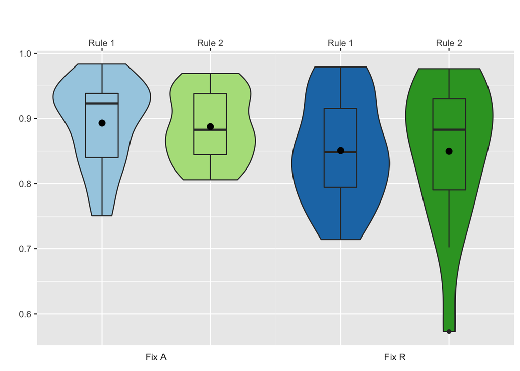

```r
gen_labeled %>%
  mutate(rule_change_cond=ifelse(rule_change_cond=='Rule edge(A)', 'Rule 1', 'Rule 2')) %>%
  ggplot(aes(x=rule_change_cond, y=cronbach_alpha, fill=condition)) +
  geom_violin() +
  geom_boxplot(width=0.3) +
  stat_summary(fun=mean, geom="point", shape=20, size=4, color="black", fill="black") +
  facet_grid(~fix_cond, switch = "x", scales = "free_x", space = "free_x") +
  # formatting
  theme(panel.spacing = unit(0, "lines"),
        strip.background = element_blank(),
        strip.placement = "outside",
        legend.position = "none") +
  labs(x='', y='', title='') +
  scale_x_discrete(position = "top") +
  scale_fill_brewer(palette="Paired")
```

```r
# Compare fixed-role condition
t.test((filter(gen_labeled, fix=='A'))$cronbach_alpha, (filter(gen_labeled, fix=='R'))$cronbach_alpha, paired = T)
```

```
##
##  Paired t-test
##
## data:  (filter(gen_labeled, fix == "A"))$cronbach_alpha and (filter(gen_labeled, fix == "R"))$cronbach_alpha
## t = 2.1167, df = 31, p-value = 0.04241
## alternative hypothesis: true difference in means is not equal to 0
## 95 percent confidence interval:
##  0.001454317 0.078307363
## sample estimates:
## mean of the differences
##              0.03988084
```

```r
# Compare evidence-balance condition
t.test((filter(gen_labeled,  rule_change=='edge'))$cronbach_alpha, (filter(gen_labeled,  rule_change=='shade'))$cronbach_alpha, paired = T)
```

```
##
##  Paired t-test
##
## data:  (filter(gen_labeled, rule_change == "edge"))$cronbach_alpha and (filter(gen_labeled, rule_change == "shade"))$cronbach_alpha
## t = 0.22135, df = 31, p-value = 0.8263
## alternative hypothesis: true difference in means is not equal to 0
## 95 percent confidence interval:
##  -0.02723416  0.03386545
## sample estimates:
## mean of the differences
##             0.003315642
```

```r
# Test linear models
lm(cronbach_alpha~fix+rule_change, data=gen_labeled) %>% summary
```

```
##
## Call:
## lm(formula = cronbach_alpha ~ fix + rule_change, data = gen_labeled)
##
## Residuals:
##       Min        1Q    Median        3Q       Max
## -0.276112 -0.052966  0.001044  0.053508  0.127872
##
## Coefficients:
##                   Estimate Std. Error t value Pr(>|t|)
## (Intercept)       0.891807   0.017263  51.661   <2e-16 ***
## fixR             -0.039881   0.019933  -2.001   0.0499 *
## rule_changeshade -0.003316   0.019933  -0.166   0.8684
## ---
## Signif. codes:  0 '***' 0.001 '**' 0.01 '*' 0.05 '.' 0.1 ' ' 1
##
## Residual standard error: 0.07973 on 61 degrees of freedom
## Multiple R-squared:  0.06198,    Adjusted R-squared:  0.03122
## F-statistic: 2.015 on 2 and 61 DF,  p-value: 0.1421
```

```r
lm(cronbach_alpha~fix+rule_change+fix:rule_change, data=gen_labeled) %>% summary
```

```
##
## Call:
## lm(formula = cronbach_alpha ~ fix + rule_change + fix:rule_change,
##     data = gen_labeled)
##
## Residuals:
##       Min        1Q    Median        3Q       Max
## -0.277247 -0.053880  0.001572  0.054643  0.128327
##
## Coefficients:
##                        Estimate Std. Error t value Pr(>|t|)
## (Intercept)            0.892941   0.020097  44.433   <2e-16 ***
## fixR                  -0.042150   0.028421  -1.483    0.143
## rule_changeshade      -0.005585   0.028421  -0.197    0.845
## fixR:rule_changeshade  0.004538   0.040193   0.113    0.910
## ---
## Signif. codes:  0 '***' 0.001 '**' 0.01 '*' 0.05 '.' 0.1 ' ' 1
##
## Residual standard error: 0.08039 on 60 degrees of freedom
## Multiple R-squared:  0.06218,    Adjusted R-squared:  0.01529
## F-statistic: 1.326 on 3 and 60 DF,  p-value: 0.2743
```

We found that generalization consistency decreased as objects in the generalization tasks become more distinct from those in the learning examples. To show this, we constructed a rough measure of *dissimilarity*, by counting the features of generalization trials that took novel values never observed in the learning phase. See Section “Generalization Consistency” for Experiment 2 on page 16.

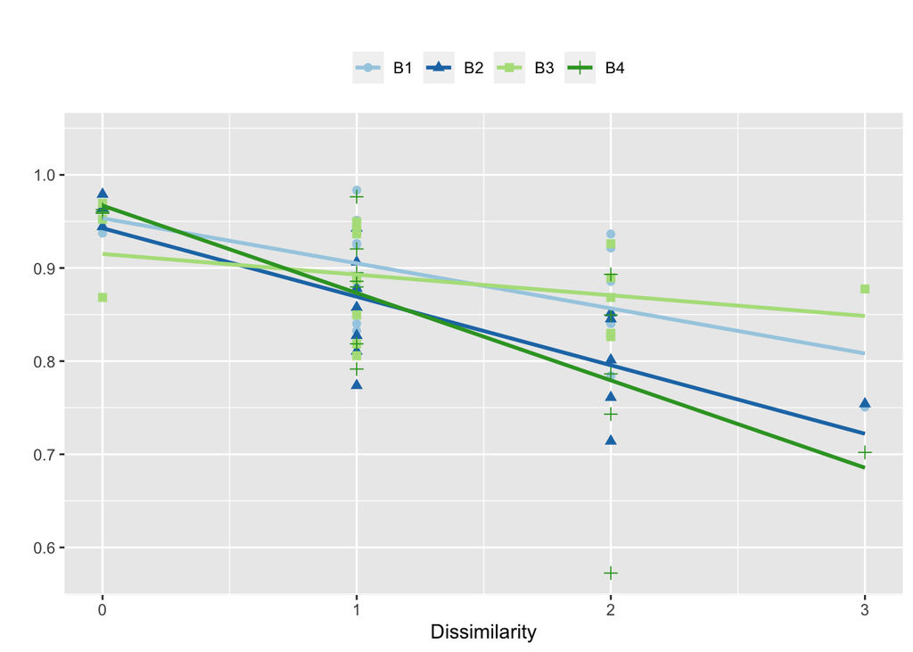

```r
get_stone_overlaps<-function(vec_a, vec_b) {
  appeared_shades<-unique(vec_a%%10)
  appeared_edges<-unique(floor(vec_a/10))
  tasked_shades<-unique(vec_b%%10)
  tasked_edges<-unique(floor(vec_b/10))
  return(2-max(tasked_edges %in% appeared_edges)-max(tasked_shades %in% appeared_shades))
}

for (i in 1:nrow(gen_labeled)) {
  cond=gen_labeled[i, 'condition']
  tid=gen_labeled[i, 'trial']
  agent=filter(tasks, phase=='gen', condition==cond, task==tid) %>% pull(agent)
  recipient=filter(tasks, phase=='gen', condition==cond, task==tid) %>% pull(recipient)
  all_tasked<-c(agent, recipient) %>% unique()
  # Get learning data
  learn_agents<-filter(tasks, phase=='learn', condition==cond) %>% pull(agent) %>% unique()
  learn_recipient<-filter(tasks, phase=='learn', condition==cond) %>% pull(recipient) %>% unique()
  all_appeared<-c(learn_agents, learn_recipient) %>% unique()
  # calculate different measurements
  gen_labeled[i, 'agent_diff']<-get_stone_overlaps(learn_agents, agent)
  gen_labeled[i, 'recipient_diff']<-get_stone_overlaps(learn_recipient, recipient)
  gen_labeled[i, 'fixed_diff']<-ifelse(cond %in% c('A1', 'A3'), gen_labeled[i, 'agent_diff'], gen_labeled[i, 'recipient_diff'])
  gen_labeled[i, 'varied_diff']<-ifelse(cond %in% c('A1', 'A3'), gen_labeled[i, 'recipient_diff'], gen_labeled[i, 'agent_diff'])
}

gen_labeled$total_diff<-gen_labeled$fixed_diff+gen_labeled$varied_diff

# Plot Cronbach alpha's changes with dissimilarity
gen_labeled %>%
  mutate(condition=gsub('A', 'B', condition)) %>%
  ggplot(aes(x=total_diff, y=cronbach_alpha, shape=condition, color=condition)) +
  geom_point(size=2) +
  geom_smooth(method = "lm", fill=NA) +
  scale_color_brewer(palette="Paired") +
  labs(x='Dissimilarity', y='', title='') +
  theme(legend.title = element_blank(),
        legend.position="top")
```

```r
# Test with linear regression
lm(cronbach_alpha~total_diff, data=gen_labeled) %>% summary()
```

```
##
## Call:
## lm(formula = cronbach_alpha ~ total_diff, data = gen_labeled)
##
## Residuals:
##       Min        1Q    Median        3Q       Max
## -0.253088 -0.039772  0.005561  0.040492  0.111435
##
## Coefficients:
##              Estimate Std. Error t value Pr(>|t|)
## (Intercept)  0.944579   0.014578  64.794  < 2e-16 ***
## total_diff  -0.059496   0.009719  -6.122 6.92e-08 ***
## ---
## Signif. codes:  0 '***' 0.001 '**' 0.01 '*' 0.05 '.' 0.1 ' ' 1
##
## Residual standard error: 0.06447 on 62 degrees of freedom
## Multiple R-squared:  0.3767, Adjusted R-squared:  0.3667
## F-statistic: 37.48 on 1 and 62 DF,  p-value: 6.922e-08
```

```r
# Take conditions into account
lm(cronbach_alpha~total_diff+fix+rule_change, gen_labeled) %>% summary()
```

```
##
## Call:
## lm(formula = cronbach_alpha ~ total_diff + fix + rule_change,
##     data = gen_labeled)
##
## Residuals:
##      Min       1Q   Median       3Q      Max
## -0.23149 -0.04008  0.00901  0.03966  0.11300
##
## Coefficients:
##                   Estimate Std. Error t value Pr(>|t|)
## (Intercept)       0.966177   0.017850  54.127  < 2e-16 ***
## total_diff       -0.059496   0.009375  -6.346 3.22e-08 ***
## fixR             -0.039881   0.015547  -2.565   0.0128 *
## rule_changeshade -0.003316   0.015547  -0.213   0.8318
## ---
## Signif. codes:  0 '***' 0.001 '**' 0.01 '*' 0.05 '.' 0.1 ' ' 1
##
## Residual standard error: 0.06219 on 60 degrees of freedom
## Multiple R-squared:  0.4387, Adjusted R-squared:  0.4106
## F-statistic: 15.63 on 3 and 60 DF,  p-value: 1.264e-07
```

```r
lm(cronbach_alpha~agent_diff, gen_labeled) %>% summary()
```

```
##
## Call:
## lm(formula = cronbach_alpha ~ agent_diff, data = gen_labeled)
##
## Residuals:
##      Min       1Q   Median       3Q      Max
## -0.30571 -0.04782  0.01456  0.06689  0.11815
##
## Coefficients:
##             Estimate Std. Error t value Pr(>|t|)
## (Intercept)  0.87821    0.01363  64.411   <2e-16 ***
## agent_diff  -0.01280    0.01458  -0.878    0.383
## ---
## Signif. codes:  0 '***' 0.001 '**' 0.01 '*' 0.05 '.' 0.1 ' ' 1
##
## Residual standard error: 0.08116 on 62 degrees of freedom
## Multiple R-squared:  0.01229,    Adjusted R-squared:  -0.003644
## F-statistic: 0.7713 on 1 and 62 DF,  p-value: 0.3832
```

```r
lm(cronbach_alpha~recipient_diff, gen_labeled) %>% summary()
```

```
##
## Call:
## lm(formula = cronbach_alpha ~ recipient_diff, data = gen_labeled)
##
## Residuals:
##      Min       1Q   Median       3Q      Max
## -0.19920 -0.03356  0.01293  0.04233  0.13314
##
## Coefficients:
##                Estimate Std. Error t value Pr(>|t|)
## (Intercept)     0.91499    0.01076  85.039  < 2e-16 ***
## recipient_diff -0.07165    0.01150  -6.229 4.56e-08 ***
## ---
## Signif. codes:  0 '***' 0.001 '**' 0.01 '*' 0.05 '.' 0.1 ' ' 1
##
## Residual standard error: 0.06404 on 62 degrees of freedom
## Multiple R-squared:  0.3849, Adjusted R-squared:  0.375
## F-statistic:  38.8 on 1 and 62 DF,  p-value: 4.555e-08
```

# Self-reports

Since our ground truths are not the only rules consistent with the learning data, we analyzed participant self-reports not according to whether they got the ground truths right, but whether their own rules were consistent with the learning data, as well as the level of generality in the reports. Hence, we first defined three exclusive and exhaustive response specificity categories: *specific*, *fuzzy*, and *tacit*. See section “Self-reports” for Experiment 2, pp.17-18.

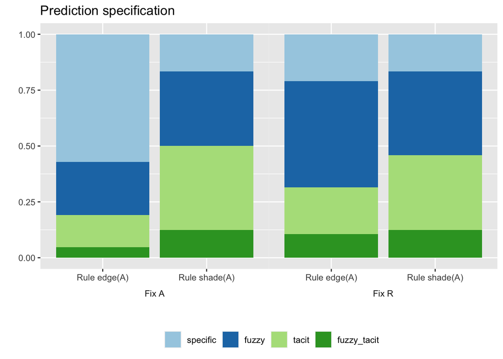

```r
ggplot(comp_data, aes(x=rule_change_cond, fill=rule_type)) +
  geom_bar(stat="count", position="fill") +
  facet_grid(~fix_cond, switch = "x", scales = "free_x", space = "free_x") +
  theme(panel.spacing = unit(0, "lines"),
        strip.background = element_blank(),
        strip.placement = "outside") +
  labs(x='', y='', title='Prediction specification') +
  theme(legend.title = element_blank(), legend.position = 'bottom') +
  scale_fill_brewer(palette="Paired")
```

```r
# Test with multinom
comp_data$rule_type_2 <- relevel(comp_data$rule_type_2, ref = "specific")
test <- multinom(rule_type_2 ~ fix + rule_change, data = comp_data)
z <- summary(test)$coefficients/summary(test)$standard.errors
(1 - pnorm(abs(z), 0, 1)) * 2
```

```
##       (Intercept)       fixR rule_changeshade
## fuzzy  0.18181199 0.07150756      0.114959975
## tacit  0.09310633 0.17760162      0.008127164
```

We also had the coders categorize responses according to whether and how a self-report localized the domain of the causal law asserted. Concretely, we included four labels *A* (agent-only), *R* (recipient-only), *AR* (both), and *universal* (no localization). See section “Self-reports” for Experiment 2, pp.17-18.

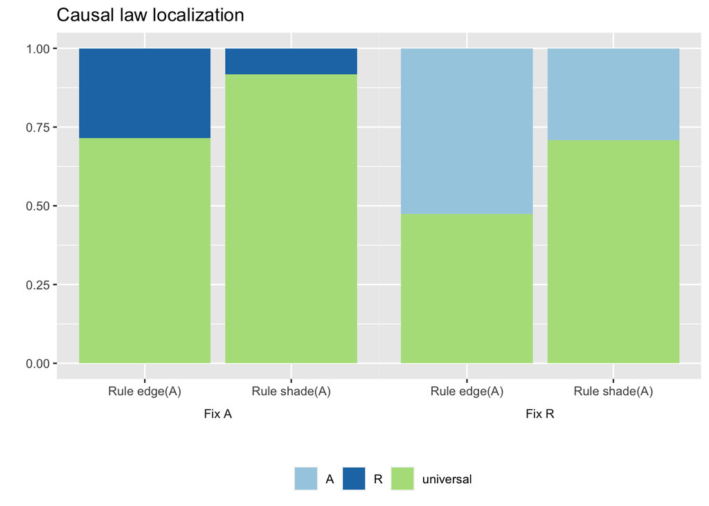

```r
ggplot(comp_data, aes(x=rule_change_cond, fill=categorization)) +
  geom_bar(stat="count", position="fill") +
  facet_grid(~fix_cond, switch = "x", scales = "free_x", space = "free_x") +
  theme(panel.spacing = unit(0, "lines"),
        strip.background = element_blank(),
        strip.placement = "outside") +
  labs(x='', y='', title='Causal law localization') +
  theme(legend.title = element_blank(), legend.position = 'bottom') +
  scale_fill_brewer(palette="Paired")
```

```r
# Test localization with GLM
glm(categorization=='universal' ~ fix + rule_change,
    data=comp_data, family='binomial') %>% summary()
```

```
##
## Call:
## glm(formula = categorization == "universal" ~ fix + rule_change,
##     family = "binomial", data = comp_data)
##
## Deviance Residuals:
##     Min       1Q   Median       3Q      Max
## -2.1415  -1.0958   0.4614   0.8003   1.2613
##
## Coefficients:
##                  Estimate Std. Error z value Pr(>|z|)
## (Intercept)        1.0173     0.4372   2.327   0.0200 *
## fixR              -1.2122     0.5209  -2.327   0.0200 *
## rule_changeshade   1.1692     0.5135   2.277   0.0228 *
## ---
## Signif. codes:  0 '***' 0.001 '**' 0.01 '*' 0.05 '.' 0.1 ' ' 1
##
## (Dispersion parameter for binomial family taken to be 1)
##
##     Null deviance: 105.033  on 87  degrees of freedom
## Residual deviance:  94.362  on 85  degrees of freedom
## AIC: 100.36
##
## Number of Fisher Scoring iterations: 4
```

```r
glm(categorization=='universal' ~ fix + rule_change + fix:rule_change,
    data=comp_data, family='binomial') %>% summary()
```

```
##
## Call:
## glm(formula = categorization == "universal" ~ fix + rule_change +
##     fix:rule_change, family = "binomial", data = comp_data)
##
## Deviance Residuals:
##     Min       1Q   Median       3Q      Max
## -2.2293  -1.1330   0.4172   0.8305   1.2225
##
## Coefficients:
##                       Estimate Std. Error z value Pr(>|z|)
## (Intercept)             0.9163     0.4830   1.897   0.0578 .
## fixR                   -1.0217     0.6667  -1.532   0.1254
## rule_changeshade        1.4816     0.8825   1.679   0.0932 .
## fixR:rule_changeshade  -0.4889     1.0916  -0.448   0.6542
## ---
## Signif. codes:  0 '***' 0.001 '**' 0.01 '*' 0.05 '.' 0.1 ' ' 1
##
## (Dispersion parameter for binomial family taken to be 1)
##
##     Null deviance: 105.033  on 87  degrees of freedom
## Residual deviance:  94.157  on 84  degrees of freedom
## AIC: 102.16
##
## Number of Fisher Scoring iterations: 5
```

# Model comparison

See `./exp_2` folder for model implementations, optimized parameters, and BIC values.

Mturk data:

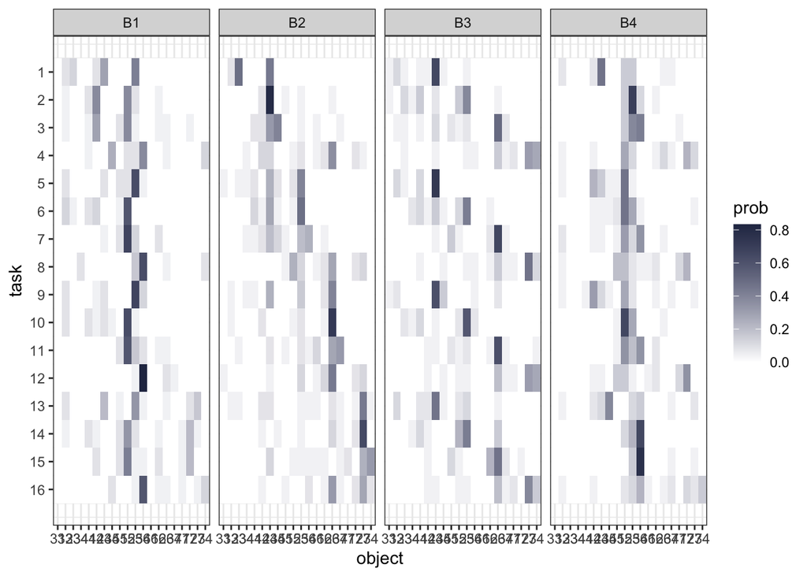

```r
# Prep desired format
all_results<-c()
for (e in 3:7) {
  for (s in 1:4) {
    all_results<-c(all_results, e*10+s)
  }
}
default<-expand.grid(condition=paste0('B', seq(4)), trial=seq(16), result=all_results)
default$condition<-as.character(default$condition)

# Format mturk behavioral data
beh<-df.tw %>%
  filter(phase=='gen'&grepl('gen', sid)) %>%
  mutate(trial=as.numeric(substr(sid,8,9)),
         condition=paste0('B',substr(condition,2,2))) %>%
  select(ix, condition, trial, result) %>%
  arrange(condition, trial) %>%
  group_by(condition, trial, result) %>%
  summarise(count=n()) %>%
  ungroup() %>%
  right_join(default, by=c('condition', 'trial', 'result')) %>%
  mutate(count=replace_na(count, 0)) %>%
  group_by(condition, trial, result) %>%
  summarise(n = sum(count)) %>%
  mutate(freq = n / sum(n),
         result=as.character(result),
         data='mturk',
         ) %>%
  select(condition, trial, result, prob=freq, data)

# Plot heatmap
ggplot(beh, aes(x=result, y=trial, fill=prob)) + geom_tile() +
  labs(x='object', y='task') +
  scale_y_continuous(trans="reverse", breaks=1:16) +
  scale_fill_gradient(low='white', high='#293352') +
  facet_grid(~condition) +
  theme_bw()
```

And the best fit LoCaLa model:

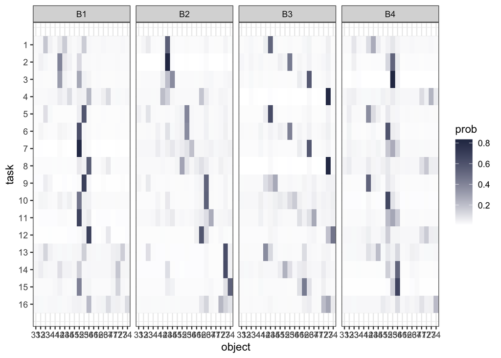

```r
# Prep data
locala<-model.proc %>%
  mutate(condition=paste0('B',substr(group,2,2)), result=object, data='LoCaLa') %>%
  select(condition, trial, result, prob=prob_s, data)

# Plot heatmap
ggplot(locala, aes(x=result, y=trial, fill=prob)) + geom_tile() +
  labs(x='object', y='task') +
  scale_y_continuous(trans="reverse", breaks=1:16) +
  scale_fill_gradient(low='white', high='#293352') +
  facet_grid(~condition) +
  theme_bw()
```